# **Deep Learning Project: Street View Housing Number Digit Recognition**

# **Marks: 60**

## **Context**

One of the most interesting tasks in deep learning is to recognize objects in natural scenes. The ability to process visual information using machine learning algorithms can be very useful as demonstrated in various applications.

The SVHN dataset contains over 600,000 labeled digits cropped from street-level photos. It is one of the most popular image recognition datasets. It has been used in neural networks created by Google to improve the map quality by automatically transcribing the address numbers from a patch of pixels. The transcribed number with a known street address helps pinpoint the location of the building it represents.

## **Objective**

Our objective is to predict the number depicted inside the image by using Artificial or Fully Connected Feed Forward Neural Networks and Convolutional Neural Networks. We will go through various models of each and finally select the one that is giving us the best performance.

## **Dataset**

Here, we will use a subset of the original data to save some computation time. The dataset is provided as a .h5 file. The basic preprocessing steps have been applied on the dataset.

## **Mount the drive**

Let us start by mounting the Google drive. You can run the below cell to mount the Google drive.

```python
from google.colab import drive
drive.mount('/content/drive')
```

## **Importing the necessary libraries**

```python
import numpy as np
import pandas as pd

import matplotlib.pyplot as plt
import seaborn as sns

#For visualizing data
import cv2
import seaborn as sns

#For building models
import tensorflow as tf
import keras
from tensorflow.keras.models import Sequential, Model
from tensorflow.keras.layers import Dense, Conv2D, MaxPooling2D, BatchNormalization, Activation, Input, LeakyReLU, Dropout, Flatten
from tensorflow.keras import backend
from tensorflow.keras.utils import to_categorical
from tensorflow.keras.optimizers import Adam, SGD, RMSprop
from tensorflow.keras.callbacks import EarlyStopping, ModelCheckpoint
from tensorflow.keras import losses, optimizers
from tensorflow.keras.preprocessing.image import load_img
from google.colab.patches import cv2_imshow

import warnings
warnings.filterwarnings('ignore')
```

**Let us check the version of tensorflow.**

```python
print(tf.__version__)
```

```
2.17.0
```

## **Load the dataset**

- Let us now load the dataset that is available as a .h5 file.
- Split the data into the train and the test dataset.

```python
import h5py

#Opening file
h5f = h5py.File('/content/drive/MyDrive/SVHN_single_grey1.h5', 'r')

#Loading datasets
X_train = h5f['X_train'][:]
y_train = h5f['y_train'][:]
X_test = h5f['X_test'][:]
y_test = h5f['y_test'][:]

#Closing file
h5f.close()
```

Check the number of images in the training and the testing dataset.

```python
len(X_train), len(X_test)
```

```
(42000, 18000)
```

**Observation:** There are 42000 images in the training data and 18000 images in the testing data

## **Visualizing images**

- Use X_train to visualize the first 10 images.
- Use Y_train to print the first 10 labels.

```
label for the images: [2 6 7 4 4 0 3 0 7 3]
```

```python
plt.figure(figsize=(10,10))

for i in range (10):
  plt.subplot(1, 10, i+1)
  plt.imshow(X_train[i], cmap='gray')
  plt.axis('off')

plt.show()

print('label for the images: %s' % (y_train[0:10]))
```

[output not shown]

```python
X_test.shape
```

```
(18000, 32, 32)
```

```python
X_train.shape
```

```
(42000, 32, 32)
```

```python
y_test.shape
```

```
(18000,)
```

```python
y_train.shape
```

```
(42000,)
```

## **Data preparation**

- Print the shape and the array of pixels for the first image in the training dataset.
- Normalize the train and the test dataset by dividing by 255.
- Print the new shapes of the train and the test dataset.
- One-hot encode the target variable.

```python
print ("Shape", X_train[0].shape)

print ()

print ("First Image:\n", X_train[0])
```

```
Shape (32, 32)

First Image:
 [[ 33.0704  30.2601  26.852  ...  71.4471  58.2204  42.9939]
 [ 25.2283  25.5533  29.9765 ... 113.0209 103.3639  84.2949]
 [ 26.2775  22.6137  40.4763 ... 113.3028 121.775  115.4228]
 ...
 [ 28.5502  36.212   45.0801 ...  24.1359  25.0927  26.0603]
 [ 38.4352  26.4733  23.2717 ...  28.1094  29.4683  30.0661]
 [ 50.2984  26.0773  24.0389 ...  49.6682  50.853   53.0377]]
```

```python
X_train = X_train.reshape(X_train.shape[0], 1024)  #1024 because the images were the size 32x32 at the beginning
X_test = X_test.reshape(X_test.shape[0], 1024)
```

### **Normalize the train and the test data**

```python
X_train = X_train/255.0
X_test = X_test/255.0
```

Print the shapes of Training and Test data

```python
print('Training set:', X_train.shape, y_train.shape)
print('Test set:', X_test.shape, y_test.shape)
```

```
Training set: (42000, 1024) (42000,)
Test set: (18000, 1024) (18000,)
```

### **One-hot encode output**

```python
y_train = to_categorical(y_train)

y_test = to_categorical(y_test)
```

```python
y_test
```

```
array([[0., 1., 0., ..., 0., 0., 0.],
       [0., 0., 0., ..., 1., 0., 0.],
       [0., 0., 1., ..., 0., 0., 0.],
       ...,
       [0., 0., 0., ..., 1., 0., 0.],
       [0., 0., 0., ..., 0., 0., 1.],
       [0., 0., 1., ..., 0., 0., 0.]])
```

```python
y_train
```

```
array([[0., 0., 1., ..., 0., 0., 0.],
       [0., 0., 0., ..., 0., 0., 0.],
       [0., 0., 0., ..., 1., 0., 0.],
       ...,
       [0., 0., 0., ..., 1., 0., 0.],
       [1., 0., 0., ..., 0., 0., 0.],
       [0., 0., 0., ..., 0., 0., 0.]])
```

**Observation:** The data is now suitable for a classification task, the model treats each class independently.

## **Model Building**

Now that we have done the data preprocessing, let's build an ANN model.

### Fix the seed for random number generators

```python
from tensorflow.keras import backend
backend.clear_session()

np.random.seed(42)
import random
random.seed(42)
tf.random.set_seed(42)
```

### **Model Architecture**

- Write a function that returns a sequential model with the following architecture:
  - First hidden layer with **64 nodes and the relu activation** and the **input shape = (1024, )**
  - Second hidden layer with **32 nodes and the relu activation**
  - Output layer with **activation as 'softmax' and number of nodes equal to the number of classes, i.e., 10**
  - Compile the model with the **loss equal to categorical_crossentropy, optimizer equal to Adam(learning_rate = 0.001), and metric equal to 'accuracy'**. Do not fit the model here, just return the compiled model.
- Call the nn_model_1 function and store the model in a new variable.
- Print the summary of the model.
- Fit on the train data with a **validation split of 0.2, batch size = 128, verbose = 1, and epochs = 20**. Store the model building history to use later for visualization.

### **Build and train an ANN model as per the above mentioned architecture.**

```python
#Defining model, storing the model in nn_model_1 variable
def nn_model_1():

  model = Sequential()

  #Adding layers as given above
  model.add(Dense(64, input_shape=(1024,), activation='relu'))
  model.add(Dense(32, activation='relu'))
  model.add(Dense(10, activation='softmax'))

  #Compiling model
  model.compile(loss='categorical_crossentropy', optimizer=Adam(learning_rate=0.001), metrics=['accuracy'])

  return model
```

```python
#Building the model and printing the summary

model_1 = nn_model_1()
model_1.summary()
```

```
Model: "sequential"
```

```
┏━━━━━━━━━━━━━━━━━━━━━━━━━━━━━━━━━━━━━━┳━━━━━━━━━━━━━━━━━━━━━━━━━━━━━┳━━━━━━━━━━━━━━━━━┓
┃ Layer (type)                         ┃ Output Shape                ┃         Param # ┃
┡━━━━━━━━━━━━━━━━━━━━━━━━━━━━━━━━━━━━━━╇━━━━━━━━━━━━━━━━━━━━━━━━━━━━━╇━━━━━━━━━━━━━━━━━┩
│ dense (Dense)                        │ (None, 64)                  │          65,600 │
├──────────────────────────────────────┼─────────────────────────────┼─────────────────┤
│ dense_1 (Dense)                      │ (None, 32)                  │           2,080 │
├──────────────────────────────────────┼─────────────────────────────┼─────────────────┤
│ dense_2 (Dense)                      │ (None, 10)                  │             330 │
└──────────────────────────────────────┴─────────────────────────────┴─────────────────┘
```

```
 Total params: 68,010 (265.66 KB)
```

```
 Trainable params: 68,010 (265.66 KB)
```

```
 Non-trainable params: 0 (0.00 B)
```

```python
#Fitting the model, fit the instructions given above

history_model_1 = model_1.fit(
                  X_train, y_train,
                  validation_split=0.2,
                  batch_size=128,
                  verbose=1,
                  epochs=20
                  )
```

```
263/263 ━━━━━━━━━━━━━━━━━━━━ 3s 6ms/step - accuracy: 0.1073 - loss: 2.3092 - val_accuracy: 0.1632 - val_loss: 2.2677
263/263 ━━━━━━━━━━━━━━━━━━━━ 1s 2ms/step - accuracy: 0.1778 - loss: 2.2184 - val_accuracy: 0.2912 - val_loss: 2.0361
263/263 ━━━━━━━━━━━━━━━━━━━━ 1s 2ms/step - accuracy: 0.3392 - loss: 1.9184 - val_accuracy: 0.4385 - val_loss: 1.6545
263/263 ━━━━━━━━━━━━━━━━━━━━ 1s 2ms/step - accuracy: 0.4624 - loss: 1.6101 - val_accuracy: 0.5181 - val_loss: 1.4750
263/263 ━━━━━━━━━━━━━━━━━━━━ 1s 2ms/step - accuracy: 0.5248 - loss: 1.4636 - val_accuracy: 0.5379 - val_loss: 1.4121
263/263 ━━━━━━━━━━━━━━━━━━━━ 1s 2ms/step - accuracy: 0.5540 - loss: 1.3859 - val_accuracy: 0.5629 - val_loss: 1.3575
263/263 ━━━━━━━━━━━━━━━━━━━━ 1s 3ms/step - accuracy: 0.5754 - loss: 1.3312 - val_accuracy: 0.5846 - val_loss: 1.3061
263/263 ━━━━━━━━━━━━━━━━━━━━ 1s 3ms/step - accuracy: 0.5941 - loss: 1.2863 - val_accuracy: 0.6036 - val_loss: 1.2623
263/263 ━━━━━━━━━━━━━━━━━━━━ 1s 3ms/step - accuracy: 0.6098 - loss: 1.2475 - val_accuracy: 0.6164 - val_loss: 1.2286
263/263 ━━━━━━━━━━━━━━━━━━━━ 1s 3ms/step - accuracy: 0.6187 - loss: 1.2192 - val_accuracy: 0.6271 - val_loss: 1.2024
263/263 ━━━━━━━━━━━━━━━━━━━━ 1s 2ms/step - accuracy: 0.6271 - loss: 1.1962 - val_accuracy: 0.6305 - val_loss: 1.1856
263/263 ━━━━━━━━━━━━━━━━━━━━ 1s 2ms/step - accuracy: 0.6314 - loss: 1.1792 - val_accuracy: 0.6362 - val_loss: 1.1702
263/263 ━━━━━━━━━━━━━━━━━━━━ 1s 2ms/step - accuracy: 0.6382 - loss: 1.1630 - val_accuracy: 0.6390 - val_loss: 1.1578
263/263 ━━━━━━━━━━━━━━━━━━━━ 1s 2ms/step - accuracy: 0.6417 - loss: 1.1504 - val_accuracy: 0.6413 - val_loss: 1.1474
263/263 ━━━━━━━━━━━━━━━━━━━━ 1s 2ms/step - accuracy: 0.6448 - loss: 1.1413 - val_accuracy: 0.6455 - val_loss: 1.1367
263/263 ━━━━━━━━━━━━━━━━━━━━ 1s 2ms/step - accuracy: 0.6488 - loss: 1.1292 - val_accuracy: 0.6493 - val_loss: 1.1262
263/263 ━━━━━━━━━━━━━━━━━━━━ 1s 2ms/step - accuracy: 0.6526 - loss: 1.1185 - val_accuracy: 0.6540 - val_loss: 1.1166
263/263 ━━━━━━━━━━━━━━━━━━━━ 1s 2ms/step - accuracy: 0.6545 - loss: 1.1099 - val_accuracy: 0.6567 - val_loss: 1.1068
263/263 ━━━━━━━━━━━━━━━━━━━━ 1s 2ms/step - accuracy: 0.6583 - loss: 1.1021 - val_accuracy: 0.6588 - val_loss: 1.1010
263/263 ━━━━━━━━━━━━━━━━━━━━ 1s 2ms/step - accuracy: 0.6609 - loss: 1.0949 - val_accuracy: 0.6607 - val_loss: 1.0959
```

### **Plot the Training and Validation Accuracies and write down your Observations.**

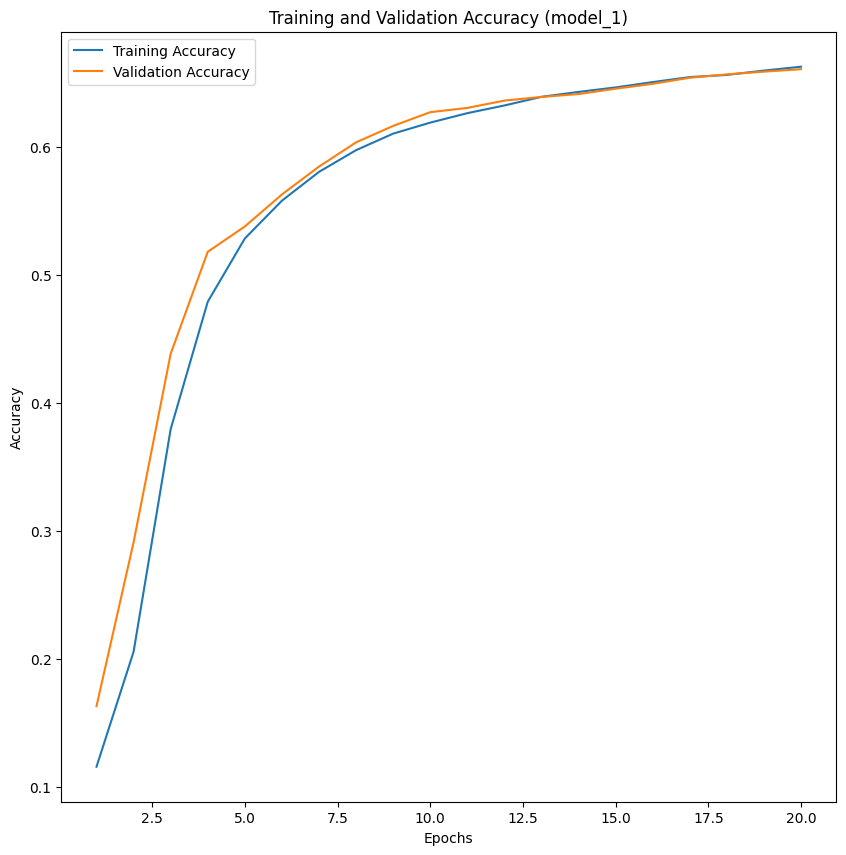

```python
#Plotting the training and validation accuracies

dict_hist = history_model_1.history

list_ep = [i for i in range(1, 21)]
plt.figure(figsize=(10, 10))
plt.title('Training and Validation Accuracy (model_1)')
plt.plot(list_ep, dict_hist['accuracy'], label='Training Accuracy')
plt.plot(list_ep, dict_hist['val_accuracy'], label='Validation Accuracy')
plt.xlabel('Epochs')
plt.ylabel('Accuracy')
plt.legend()
plt.show()
```

**Observations:**

- Both validation and training accuracy increased and converged toward each other.
- After around 5 epochs both of the curves rise at a seemingly similar pace and stay close to each other, that means that the model isn't overfitting inordinately.
- At around epoch 20 the model reaches an accuracy close to 0.7 for both training and validation
- The model seems to generealize well. It does not plateau at higher value, therefore it might be possible that we could reach better performance.

Let's build one more model with higher complexity and see if we can improve the performance of the model.

First, we need to clear the previous model's history from the Keras backend. Also, let's fix the seed again after clearing the backend.

```python
from tensorflow.keras import backend
backend.clear_session()

np.random.seed(42)
import random
random.seed(42)
tf.random.set_seed(42)
```

### **Second Model Architecture**

- Write a function that returns a sequential model with the following architecture:
  - First hidden layer with **256 nodes and the relu activation** and the **input shape = (1024, )**
  - Second hidden layer with **128 nodes and the relu activation**
  - Add the **Dropout layer with the rate equal to 0.2**
  - Third hidden layer with **64 nodes and the relu activation**
  - Fourth hidden layer with **64 nodes and the relu activation**
  - Fifth hidden layer with **32 nodes and the relu activation**
  - Add the **BatchNormalization layer**
  - Output layer with **activation as 'softmax' and number of nodes equal to the number of classes, i.e., 10** -Compile the model with the **loss equal to categorical_crossentropy, optimizer equal to Adam(learning_rate = 0.0005), and metric equal to 'accuracy'**. Do not fit the model here, just return the compiled model.
- Call the nn_model_2 function and store the model in a new variable.
- Print the summary of the model.
- Fit on the train data with a **validation split of 0.2, batch size = 128, verbose = 1, and epochs = 30**. Store the model building history to use later for visualization.

### **Build and train the new ANN model as per the above mentioned architecture**

```python
#Defining nn_model_2

def nn_model_2():

  model = Sequential()

  #Adding layers as given above

  model.add(Dense(256, input_shape=(1024,), activation='relu'))
  model.add(Dense(128, activation='relu'))
  model.add(Dropout(0.2))
  model.add(Dense(64, activation='relu'))
  model.add(Dense(64, activation='relu'))
  model.add(Dense(32, activation='relu'))
  model.add(BatchNormalization())
  model.add(Dense(10, activation='softmax'))

  #Compiling model
  model.compile(loss='categorical_crossentropy', optimizer=Adam(learning_rate=0.0005), metrics=['accuracy'])

  return model
```

```python
#Building the model and printing the summary

model_2 = nn_model_2()
model_2.summary()
```

```
Model: "sequential"
```

```
┏━━━━━━━━━━━━━━━━━━━━━━━━━━━━━━━━━━━━━━┳━━━━━━━━━━━━━━━━━━━━━━━━━━━━━┳━━━━━━━━━━━━━━━━━┓
┃ Layer (type)                         ┃ Output Shape                ┃         Param # ┃
┡━━━━━━━━━━━━━━━━━━━━━━━━━━━━━━━━━━━━━━╇━━━━━━━━━━━━━━━━━━━━━━━━━━━━━╇━━━━━━━━━━━━━━━━━┩
│ dense (Dense)                        │ (None, 256)                 │         262,400 │
├──────────────────────────────────────┼─────────────────────────────┼─────────────────┤
│ dense_1 (Dense)                      │ (None, 128)                 │          32,896 │
├──────────────────────────────────────┼─────────────────────────────┼─────────────────┤
│ dropout (Dropout)                    │ (None, 128)                 │               0 │
├──────────────────────────────────────┼─────────────────────────────┼─────────────────┤
│ dense_2 (Dense)                      │ (None, 64)                  │           8,256 │
├──────────────────────────────────────┼─────────────────────────────┼─────────────────┤
│ dense_3 (Dense)                      │ (None, 64)                  │           4,160 │
├──────────────────────────────────────┼─────────────────────────────┼─────────────────┤
│ dense_4 (Dense)                      │ (None, 32)                  │           2,080 │
├──────────────────────────────────────┼─────────────────────────────┼─────────────────┤
│ batch_normalization                  │ (None, 32)                  │             128 │
│ (BatchNormalization)                 │                             │                 │
├──────────────────────────────────────┼─────────────────────────────┼─────────────────┤
│ dense_5 (Dense)                      │ (None, 10)                  │             330 │
└──────────────────────────────────────┴─────────────────────────────┴─────────────────┘
```

```
 Total params: 310,250 (1.18 MB)
```

```
 Trainable params: 310,186 (1.18 MB)
```

```
 Non-trainable params: 64 (256.00 B)
```

```python
#Fitting the model

history_model_2 = model_2.fit(
                  X_train, y_train,
                  validation_split=0.2,
                  batch_size=128,
                  verbose=1,
                  epochs=30
                  )
```

```
263/263 ━━━━━━━━━━━━━━━━━━━━ 8s 14ms/step - accuracy: 0.1004 - loss: 2.4449 - val_accuracy: 0.1004 - val_loss: 2.3076
263/263 ━━━━━━━━━━━━━━━━━━━━ 5s 3ms/step - accuracy: 0.1054 - loss: 2.3053 - val_accuracy: 0.1207 - val_loss: 2.2908
263/263 ━━━━━━━━━━━━━━━━━━━━ 1s 3ms/step - accuracy: 0.2072 - loss: 2.1583 - val_accuracy: 0.3894 - val_loss: 1.8765
263/263 ━━━━━━━━━━━━━━━━━━━━ 1s 3ms/step - accuracy: 0.4246 - loss: 1.6725 - val_accuracy: 0.5320 - val_loss: 1.4290
263/263 ━━━━━━━━━━━━━━━━━━━━ 2s 4ms/step - accuracy: 0.5301 - loss: 1.4109 - val_accuracy: 0.5907 - val_loss: 1.2491
263/263 ━━━━━━━━━━━━━━━━━━━━ 1s 4ms/step - accuracy: 0.5870 - loss: 1.2589 - val_accuracy: 0.6186 - val_loss: 1.1642
263/263 ━━━━━━━━━━━━━━━━━━━━ 1s 5ms/step - accuracy: 0.6203 - loss: 1.1771 - val_accuracy: 0.6427 - val_loss: 1.0925
263/263 ━━━━━━━━━━━━━━━━━━━━ 1s 5ms/step - accuracy: 0.6510 - loss: 1.0895 - val_accuracy: 0.6945 - val_loss: 0.9866
263/263 ━━━━━━━━━━━━━━━━━━━━ 1s 3ms/step - accuracy: 0.6636 - loss: 1.0515 - val_accuracy: 0.6924 - val_loss: 0.9687
263/263 ━━━━━━━━━━━━━━━━━━━━ 1s 3ms/step - accuracy: 0.6849 - loss: 0.9987 - val_accuracy: 0.6827 - val_loss: 0.9941
263/263 ━━━━━━━━━━━━━━━━━━━━ 1s 3ms/step - accuracy: 0.6898 - loss: 0.9760 - val_accuracy: 0.7068 - val_loss: 0.9312
263/263 ━━━━━━━━━━━━━━━━━━━━ 1s 3ms/step - accuracy: 0.6926 - loss: 0.9671 - val_accuracy: 0.7248 - val_loss: 0.8962
263/263 ━━━━━━━━━━━━━━━━━━━━ 1s 3ms/step - accuracy: 0.7065 - loss: 0.9243 - val_accuracy: 0.7214 - val_loss: 0.8975
263/263 ━━━━━━━━━━━━━━━━━━━━ 1s 3ms/step - accuracy: 0.7064 - loss: 0.9150 - val_accuracy: 0.7323 - val_loss: 0.8620
263/263 ━━━━━━━━━━━━━━━━━━━━ 1s 3ms/step - accuracy: 0.7204 - loss: 0.8894 - val_accuracy: 0.7245 - val_loss: 0.8765
263/263 ━━━━━━━━━━━━━━━━━━━━ 1s 3ms/step - accuracy: 0.7214 - loss: 0.8686 - val_accuracy: 0.7151 - val_loss: 0.9017
263/263 ━━━━━━━━━━━━━━━━━━━━ 1s 3ms/step - accuracy: 0.7223 - loss: 0.8622 - val_accuracy: 0.7462 - val_loss: 0.8250
263/263 ━━━━━━━━━━━━━━━━━━━━ 2s 5ms/step - accuracy: 0.7323 - loss: 0.8359 - val_accuracy: 0.7380 - val_loss: 0.8376
263/263 ━━━━━━━━━━━━━━━━━━━━ 1s 4ms/step - accuracy: 0.7373 - loss: 0.8260 - val_accuracy: 0.7393 - val_loss: 0.8333
263/263 ━━━━━━━━━━━━━━━━━━━━ 1s 4ms/step - accuracy: 0.7390 - loss: 0.8219 - val_accuracy: 0.7362 - val_loss: 0.8397
263/263 ━━━━━━━━━━━━━━━━━━━━ 1s 3ms/step - accuracy: 0.7397 - loss: 0.8162 - val_accuracy: 0.7515 - val_loss: 0.8017
263/263 ━━━━━━━━━━━━━━━━━━━━ 1s 3ms/step - accuracy: 0.7459 - loss: 0.8019 - val_accuracy: 0.7450 - val_loss: 0.8103
263/263 ━━━━━━━━━━━━━━━━━━━━ 1s 3ms/step - accuracy: 0.7397 - loss: 0.8113 - val_accuracy: 0.7601 - val_loss: 0.7759
263/263 ━━━━━━━━━━━━━━━━━━━━ 1s 3ms/step - accuracy: 0.7537 - loss: 0.7806 - val_accuracy: 0.7504 - val_loss: 0.8104
263/263 ━━━━━━━━━━━━━━━━━━━━ 1s 3ms/step - accuracy: 0.7566 - loss: 0.7669 - val_accuracy: 0.7530 - val_loss: 0.7968
263/263 ━━━━━━━━━━━━━━━━━━━━ 1s 3ms/step - accuracy: 0.7564 - loss: 0.7742 - val_accuracy: 0.7619 - val_loss: 0.7740
263/263 ━━━━━━━━━━━━━━━━━━━━ 1s 3ms/step - accuracy: 0.7623 - loss: 0.7485 - val_accuracy: 0.7530 - val_loss: 0.7929
263/263 ━━━━━━━━━━━━━━━━━━━━ 1s 3ms/step - accuracy: 0.7651 - loss: 0.7438 - val_accuracy: 0.7533 - val_loss: 0.7977
263/263 ━━━━━━━━━━━━━━━━━━━━ 1s 4ms/step - accuracy: 0.7671 - loss: 0.7360 - val_accuracy: 0.7642 - val_loss: 0.7638
263/263 ━━━━━━━━━━━━━━━━━━━━ 1s 4ms/step - accuracy: 0.7722 - loss: 0.7268 - val_accuracy: 0.7611 - val_loss: 0.7743
```

### **Plot the Training and Validation Accuracies and write down your Observations.**

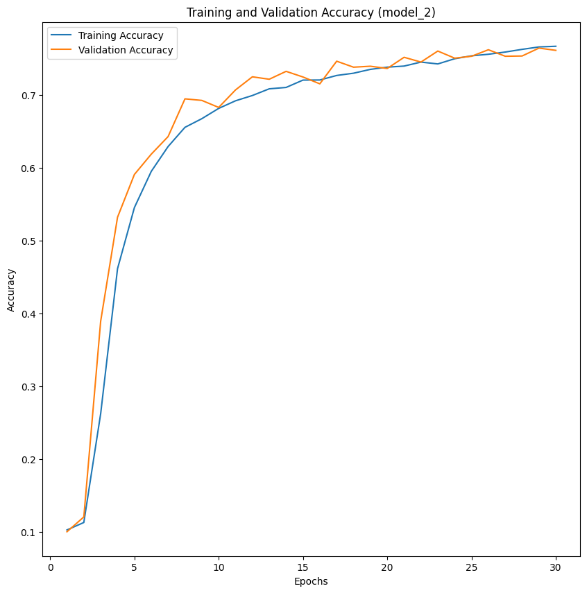

```python
#Plotting the accuracies of the second model


dict_hist = history_model_2.history

list_ep = [i for i in range(1, 31)]
plt.figure(figsize=(10, 10))
plt.title('Training and Validation Accuracy (model_2)')
plt.plot(list_ep, dict_hist['accuracy'], label='Training Accuracy')
plt.plot(list_ep, dict_hist['val_accuracy'], label='Validation Accuracy')
plt.xlabel('Epochs')
plt.ylabel('Accuracy')
plt.legend()
plt.show()
```

**Observations:**

## **Predictions on the test data**

- Make predictions on the test set using the second model.
- Print the obtained results using the classification report and the confusion matrix.
- Final observations on the obtained results.

```python
#Making predictions using the second model

test_pred = model_2.predict(X_test)

test_pred = np.argmax(test_pred, axis = -1)

#Converting each entry of y_test to a single label

y_test = np.argmax(y_test, axis = -1)
```

```
563/563 ━━━━━━━━━━━━━━━━━━━━ 2s 2ms/step
```

**Note:** Earlier, we noticed that each entry of the target variable is a one-hot encoded vector but to print the classification report and confusion matrix, we must convert each entry of y_test to a single label.

### **Print the classification report and the confusion matrix for the test predictions. Write your observations on the final results.**

```
              precision    recall  f1-score   support

           0       0.79      0.81      0.80      1814
           1       0.77      0.80      0.78      1828
           2       0.81      0.77      0.79      1803
           3       0.69      0.72      0.71      1719
           4       0.88      0.75      0.81      1812
           5       0.70      0.72      0.71      1768
           6       0.71      0.76      0.74      1832
           7       0.80      0.79      0.79      1808
           8       0.64      0.76      0.69      1812
           9       0.83      0.68      0.75      1804

    accuracy                           0.76     18000
   macro avg       0.76      0.76      0.76     18000
weighted avg       0.76      0.76      0.76     18000

[[1463   36   20   41   23   19   83   27   68   34]
 [  34 1455   29   87   29   24   38   65   55   12]
 [  15   36 1391   76   16   46   23  105   59   36]
 [  19   47   47 1245   20  163   24   50   82   22]
 [  53   60   29   28 1363   44  132   18   53   32]
 [  35   39   15  118    8 1269   90   17  140   37]
 [  80   41   11   17   47   69 1401   14  135   17]
 [  24   85  102   67    6   31   21 1421   30   21]
 [  41   44   36   45   20   66  118   23 1372   47]
 [  86   55   35   70   23   90   36   35  147 1227]]
```

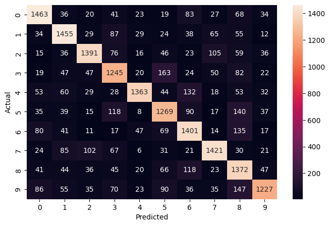

```python
#Import required functions
from sklearn.metrics import classification_report, confusion_matrix

#Print classification report
print(classification_report(y_test, test_pred))

#Print confusion matrix
print(confusion_matrix(y_test, test_pred))
cm = confusion_matrix(y_test, test_pred)
plt.figure(figsize = (8, 5))
sns.heatmap(cm, annot = True,  fmt = '.0f')
plt.ylabel('Actual')
plt.xlabel('Predicted')
plt.show()
```

## **Using Convolutional Neural Networks**

### **Load the dataset again and split the data into the train and the test dataset.**

```python
h5f = h5py.File('/content/drive/MyDrive/SVHN_single_grey1.h5', 'r')

X_train = h5f['X_train'][:]
y_train = h5f['y_train'][:]
X_test = h5f['X_test'][:]
y_test = h5f['y_test'][:]

h5f.close()
```

Check the number of images in the training and the testing dataset.

```python
len(X_train), len(X_test)
```

```
(42000, 18000)
```

**Observation:** The training data has 42000 images, the testing data has 18000 images

## **Data preparation**

- Print the shape and the array of pixels for the first image in the training dataset.
- Reshape the train and the test dataset because we always have to give a 4D array as input to CNNs.
- Normalize the train and the test dataset by dividing by 255.
- Print the new shapes of the train and the test dataset.
- One-hot encode the target variable.

```python
print('Shape', X_train[0].shape)

print()

print('First Image',X_train[0])
```

```
Shape (32, 32)

First Image [[ 33.0704  30.2601  26.852  ...  71.4471  58.2204  42.9939]
 [ 25.2283  25.5533  29.9765 ... 113.0209 103.3639  84.2949]
 [ 26.2775  22.6137  40.4763 ... 113.3028 121.775  115.4228]
 ...
 [ 28.5502  36.212   45.0801 ...  24.1359  25.0927  26.0603]
 [ 38.4352  26.4733  23.2717 ...  28.1094  29.4683  30.0661]
 [ 50.2984  26.0773  24.0389 ...  49.6682  50.853   53.0377]]
```

Reshape the dataset to be able to pass them to CNNs. Remember that we always have to give a 4D array as input to CNNs

```python
X_train = X_train.reshape(X_train.shape[0], 32, 32, 1)
X_test = X_test.reshape(X_test.shape[0], 32, 32, 1)
```

Normalize inputs from 0-255 to 0-1

```python
X_train = X_train/255.0
X_test = X_test/255.0
```

Print New shape of Training and Test

```python
print('Training set:', X_train.shape, y_train.shape)
print('Test set:', X_test.shape, y_test.shape)
```

```
Training set: (42000, 32, 32, 1) (42000,)
Test set: (18000, 32, 32, 1) (18000,)
```

### **One-hot encode the labels in the target variable y_train and y_test.**

```python
y_train = to_categorical(y_train)
y_test = to_categorical(y_test)

y_test
```

```
array([[0., 1., 0., ..., 0., 0., 0.],
       [0., 0., 0., ..., 1., 0., 0.],
       [0., 0., 1., ..., 0., 0., 0.],
       ...,
       [0., 0., 0., ..., 1., 0., 0.],
       [0., 0., 0., ..., 0., 0., 1.],
       [0., 0., 1., ..., 0., 0., 0.]])
```

**Observation:** Target variables got encoded in a one-hot encoded vector

## **Model Building**

Now that we have done data preprocessing, let's build a CNN model. Fix the seed for random number generators

```python
from tensorflow.keras import backend
backend.clear_session()

np.random.seed(42)
import random
random.seed(42)
tf.random.set_seed(42)
```

### **Model Architecture**

- **Write a function** that returns a sequential model with the following architecture:
  - First Convolutional layer with **16 filters and the kernel size of 3x3**. Use the **'same' padding** and provide the **input shape = (32, 32, 1)**
  - Add a **LeakyRelu layer** with the **slope equal to 0.1**
  - Second Convolutional layer with **32 filters and the kernel size of 3x3 with 'same' padding**
  - Another **LeakyRelu** with the **slope equal to 0.1**
  - A **max-pooling layer** with a **pool size of 2x2**
  - **Flatten** the output from the previous layer
  - Add a **dense layer with 32 nodes**
  - Add a **LeakyRelu layer with the slope equal to 0.1**
  - Add the final **output layer with nodes equal to the number of classes, i.e., 10** and **'softmax' as the activation function**
  - Compile the model with the **loss equal to categorical_crossentropy, optimizer equal to Adam(learning_rate = 0.001), and metric equal to 'accuracy'**. Do not fit the model here, just return the compiled model.
- Call the function cnn_model_1 and store the output in a new variable.
- Print the summary of the model.
- Fit the model on the training data with a **validation split of 0.2, batch size = 32, verbose = 1, and epochs = 20**. Store the model building history to use later for visualization.

### **Build and train a CNN model as per the above mentioned architecture.**

```python
#Defining model
def cnn_model_1():
  model = Sequential()

  #Adding layers according to the instrutions
  model.add(Conv2D(16, (3, 3), padding='same', input_shape=(32, 32, 1)))
  model.add(LeakyReLU(alpha=0.1))
  model.add(Conv2D(32, (3, 3), padding='same'))
  model.add(LeakyReLU(alpha=0.1))
  model.add(MaxPooling2D(pool_size=(2, 2)))
  model.add(Flatten())
  model.add(Dense(32))
  model.add(LeakyReLU(alpha=0.1))
  model.add(Dense(10, activation='softmax'))

  #Compiling model
  model.compile(loss='categorical_crossentropy', optimizer=Adam(learning_rate=0.001), metrics=['accuracy'])

  return model
```

```python
#Storing the model in a new variable and printing the summary
cnn_model_1 = cnn_model_1()
cnn_model_1.summary()
```

```
Model: "sequential"
```

```
┏━━━━━━━━━━━━━━━━━━━━━━━━━━━━━━━━━━━━━━┳━━━━━━━━━━━━━━━━━━━━━━━━━━━━━┳━━━━━━━━━━━━━━━━━┓
┃ Layer (type)                         ┃ Output Shape                ┃         Param # ┃
┡━━━━━━━━━━━━━━━━━━━━━━━━━━━━━━━━━━━━━━╇━━━━━━━━━━━━━━━━━━━━━━━━━━━━━╇━━━━━━━━━━━━━━━━━┩
│ conv2d (Conv2D)                      │ (None, 32, 32, 16)          │             160 │
├──────────────────────────────────────┼─────────────────────────────┼─────────────────┤
│ leaky_re_lu (LeakyReLU)              │ (None, 32, 32, 16)          │               0 │
├──────────────────────────────────────┼─────────────────────────────┼─────────────────┤
│ conv2d_1 (Conv2D)                    │ (None, 32, 32, 32)          │           4,640 │
├──────────────────────────────────────┼─────────────────────────────┼─────────────────┤
│ leaky_re_lu_1 (LeakyReLU)            │ (None, 32, 32, 32)          │               0 │
├──────────────────────────────────────┼─────────────────────────────┼─────────────────┤
│ max_pooling2d (MaxPooling2D)         │ (None, 16, 16, 32)          │               0 │
├──────────────────────────────────────┼─────────────────────────────┼─────────────────┤
│ flatten (Flatten)                    │ (None, 8192)                │               0 │
├──────────────────────────────────────┼─────────────────────────────┼─────────────────┤
│ dense (Dense)                        │ (None, 32)                  │         262,176 │
├──────────────────────────────────────┼─────────────────────────────┼─────────────────┤
│ leaky_re_lu_2 (LeakyReLU)            │ (None, 32)                  │               0 │
├──────────────────────────────────────┼─────────────────────────────┼─────────────────┤
│ dense_1 (Dense)                      │ (None, 10)                  │             330 │
└──────────────────────────────────────┴─────────────────────────────┴─────────────────┘
```

```
 Total params: 267,306 (1.02 MB)
```

```
 Trainable params: 267,306 (1.02 MB)
```

```
 Non-trainable params: 0 (0.00 B)
```

```python
#Fitting the model
history_cnn_model_1 = cnn_model_1.fit(
                  X_train, y_train,
                  validation_split=0.2,
                  batch_size=32,
                  verbose=1,
                  epochs=20
                  )
```

```
1050/1050 ━━━━━━━━━━━━━━━━━━━━ 6s 4ms/step - accuracy: 0.4165 - loss: 1.6412 - val_accuracy: 0.8100 - val_loss: 0.6473
1050/1050 ━━━━━━━━━━━━━━━━━━━━ 5s 4ms/step - accuracy: 0.8342 - loss: 0.5750 - val_accuracy: 0.8356 - val_loss: 0.5663
1050/1050 ━━━━━━━━━━━━━━━━━━━━ 3s 3ms/step - accuracy: 0.8656 - loss: 0.4639 - val_accuracy: 0.8520 - val_loss: 0.5126
1050/1050 ━━━━━━━━━━━━━━━━━━━━ 3s 3ms/step - accuracy: 0.8853 - loss: 0.3933 - val_accuracy: 0.8601 - val_loss: 0.4907
1050/1050 ━━━━━━━━━━━━━━━━━━━━ 6s 3ms/step - accuracy: 0.8996 - loss: 0.3391 - val_accuracy: 0.8661 - val_loss: 0.4851
1050/1050 ━━━━━━━━━━━━━━━━━━━━ 4s 3ms/step - accuracy: 0.9134 - loss: 0.2960 - val_accuracy: 0.8642 - val_loss: 0.4945
1050/1050 ━━━━━━━━━━━━━━━━━━━━ 5s 3ms/step - accuracy: 0.9239 - loss: 0.2623 - val_accuracy: 0.8646 - val_loss: 0.5177
1050/1050 ━━━━━━━━━━━━━━━━━━━━ 3s 3ms/step - accuracy: 0.9326 - loss: 0.2343 - val_accuracy: 0.8599 - val_loss: 0.5504
1050/1050 ━━━━━━━━━━━━━━━━━━━━ 6s 4ms/step - accuracy: 0.9381 - loss: 0.2071 - val_accuracy: 0.8590 - val_loss: 0.5961
1050/1050 ━━━━━━━━━━━━━━━━━━━━ 4s 4ms/step - accuracy: 0.9437 - loss: 0.1880 - val_accuracy: 0.8614 - val_loss: 0.6053
1050/1050 ━━━━━━━━━━━━━━━━━━━━ 5s 3ms/step - accuracy: 0.9480 - loss: 0.1719 - val_accuracy: 0.8629 - val_loss: 0.6263
1050/1050 ━━━━━━━━━━━━━━━━━━━━ 5s 3ms/step - accuracy: 0.9537 - loss: 0.1548 - val_accuracy: 0.8636 - val_loss: 0.6663
1050/1050 ━━━━━━━━━━━━━━━━━━━━ 3s 3ms/step - accuracy: 0.9540 - loss: 0.1486 - val_accuracy: 0.8615 - val_loss: 0.7095
1050/1050 ━━━━━━━━━━━━━━━━━━━━ 3s 3ms/step - accuracy: 0.9587 - loss: 0.1322 - val_accuracy: 0.8535 - val_loss: 0.7683
1050/1050 ━━━━━━━━━━━━━━━━━━━━ 4s 4ms/step - accuracy: 0.9582 - loss: 0.1293 - val_accuracy: 0.8401 - val_loss: 0.8400
1050/1050 ━━━━━━━━━━━━━━━━━━━━ 3s 3ms/step - accuracy: 0.9615 - loss: 0.1180 - val_accuracy: 0.8539 - val_loss: 0.8176
1050/1050 ━━━━━━━━━━━━━━━━━━━━ 3s 3ms/step - accuracy: 0.9670 - loss: 0.1025 - val_accuracy: 0.8483 - val_loss: 0.8927
1050/1050 ━━━━━━━━━━━━━━━━━━━━ 5s 3ms/step - accuracy: 0.9690 - loss: 0.0950 - val_accuracy: 0.8513 - val_loss: 0.9177
1050/1050 ━━━━━━━━━━━━━━━━━━━━ 4s 4ms/step - accuracy: 0.9684 - loss: 0.0942 - val_accuracy: 0.8493 - val_loss: 0.9291
1050/1050 ━━━━━━━━━━━━━━━━━━━━ 3s 3ms/step - accuracy: 0.9708 - loss: 0.0873 - val_accuracy: 0.8521 - val_loss: 0.9670
```

### **Plot the Training and Validation Accuracies and Write your observations.**

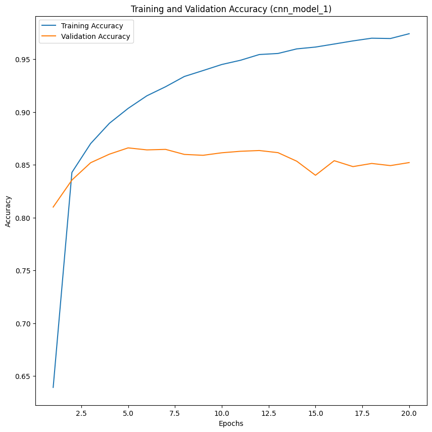

```python
dict_hist = history_cnn_model_1.history

list_ep = [i for i in range(1, 21)]
plt.figure(figsize=(10, 10))
plt.title('Training and Validation Accuracy (cnn_model_1)')
plt.plot(list_ep, dict_hist['accuracy'], label='Training Accuracy')
plt.plot(list_ep, dict_hist['val_accuracy'], label='Validation Accuracy')
plt.xlabel('Epochs')
plt.ylabel('Accuracy')
plt.legend()
plt.show()
```

Let's build another model and see if we can get a better model with generalized performance.

First, we need to clear the previous model's history from the Keras backend. Also, let's fix the seed again after clearing the backend.

```python
from tensorflow.keras import backend
backend.clear_session()

np.random.seed(42)
import random
random.seed(42)
tf.random.set_seed(42)
```

### **Second Model Architecture**

- Write a function that returns a sequential model with the following architecture:
  - First Convolutional layer with **16 filters and the kernel size of 3x3**. Use the **'same' padding** and provide the **input shape = (32, 32, 1)**
  - Add a **LeakyRelu layer** with the **slope equal to 0.1**
  - Second Convolutional layer with **32 filters and the kernel size of 3x3 with 'same' padding**
  - Add **LeakyRelu** with the **slope equal to 0.1**
  - Add a **max-pooling layer** with a **pool size of 2x2**
  - Add a **BatchNormalization layer**
  - Third Convolutional layer with **32 filters and the kernel size of 3x3 with 'same' padding**
  - Add a **LeakyRelu layer with the slope equal to 0.1**
  - Fourth Convolutional layer **64 filters and the kernel size of 3x3 with 'same' padding**
  - Add a **LeakyRelu layer with the slope equal to 0.1**
  - Add a **max-pooling layer** with a **pool size of 2x2**
  - Add a **BatchNormalization layer**
  - **Flatten** the output from the previous layer
  - Add a **dense layer with 32 nodes**
  - Add a **LeakyRelu layer with the slope equal to 0.1**
  - Add a **dropout layer with the rate equal to 0.5**
  - Add the final **output layer with nodes equal to the number of classes, i.e., 10** and **'softmax' as the activation function**
  - Compile the model with the **categorical_crossentropy loss, adam optimizers (learning_rate = 0.001), and metric equal to 'accuracy'**. Do not fit the model here, just return the compiled model.
- Call the function cnn_model_2 and store the model in a new variable.
- Print the summary of the model.
- Fit the model on the train data with a **validation split of 0.2, batch size = 128, verbose = 1, and epochs = 30**. Store the model building history to use later for visualization.

### **Build and train the second CNN model as per the above mentioned architecture.**

```python
#Defining second CNN model
def cnn_model_2():
  model = Sequential()

  #Adding layers according to the instructions
  model.add(Conv2D(16, (3, 3), padding='same', input_shape=(32, 32, 1)))        #1st convolutional layer
  model.add(LeakyReLU(alpha=0.1))
  model.add(Conv2D(32, (3, 3), padding='same'))                                 #2nd convolutional layer
  model.add(LeakyReLU(alpha=0.1))
  model.add(MaxPooling2D(pool_size=(2, 2)))
  model.add(BatchNormalization())
  model.add(Conv2D(32, (3, 3), padding='same'))                                 #3rd convolutional layer
  model.add(LeakyReLU(alpha=0.1))
  model.add(Conv2D(64, (3, 3), padding='same'))                                 #4th convolutional layer
  model.add(LeakyReLU(alpha=0.1))
  model.add(MaxPooling2D(pool_size=(2, 2)))
  model.add(BatchNormalization())
  model.add(Flatten())
  model.add(Dense(32))
  model.add(LeakyReLU(alpha=0.1))
  model.add(Dropout(0.5))
  model.add(Dense(10, activation='softmax'))

  #Compiling model
  model.compile(loss='categorical_crossentropy', optimizer=Adam(learning_rate=0.001), metrics=['accuracy'])

  return model
```

```python
#Storing cnn_model_2 in new variable and printing summary
cnn_model_2 = cnn_model_2()
cnn_model_2.summary()
```

```
Model: "sequential"
```

```
┏━━━━━━━━━━━━━━━━━━━━━━━━━━━━━━━━━━━━━━┳━━━━━━━━━━━━━━━━━━━━━━━━━━━━━┳━━━━━━━━━━━━━━━━━┓
┃ Layer (type)                         ┃ Output Shape                ┃         Param # ┃
┡━━━━━━━━━━━━━━━━━━━━━━━━━━━━━━━━━━━━━━╇━━━━━━━━━━━━━━━━━━━━━━━━━━━━━╇━━━━━━━━━━━━━━━━━┩
│ conv2d (Conv2D)                      │ (None, 32, 32, 16)          │             160 │
├──────────────────────────────────────┼─────────────────────────────┼─────────────────┤
│ leaky_re_lu (LeakyReLU)              │ (None, 32, 32, 16)          │               0 │
├──────────────────────────────────────┼─────────────────────────────┼─────────────────┤
│ conv2d_1 (Conv2D)                    │ (None, 32, 32, 32)          │           4,640 │
├──────────────────────────────────────┼─────────────────────────────┼─────────────────┤
│ leaky_re_lu_1 (LeakyReLU)            │ (None, 32, 32, 32)          │               0 │
├──────────────────────────────────────┼─────────────────────────────┼─────────────────┤
│ max_pooling2d (MaxPooling2D)         │ (None, 16, 16, 32)          │               0 │
├──────────────────────────────────────┼─────────────────────────────┼─────────────────┤
│ batch_normalization                  │ (None, 16, 16, 32)          │             128 │
│ (BatchNormalization)                 │                             │                 │
├──────────────────────────────────────┼─────────────────────────────┼─────────────────┤
│ conv2d_2 (Conv2D)                    │ (None, 16, 16, 32)          │           9,248 │
├──────────────────────────────────────┼─────────────────────────────┼─────────────────┤
│ leaky_re_lu_2 (LeakyReLU)            │ (None, 16, 16, 32)          │               0 │
├──────────────────────────────────────┼─────────────────────────────┼─────────────────┤
│ conv2d_3 (Conv2D)                    │ (None, 16, 16, 64)          │          18,496 │
├──────────────────────────────────────┼─────────────────────────────┼─────────────────┤
│ leaky_re_lu_3 (LeakyReLU)            │ (None, 16, 16, 64)          │               0 │
├──────────────────────────────────────┼─────────────────────────────┼─────────────────┤
│ max_pooling2d_1 (MaxPooling2D)       │ (None, 8, 8, 64)            │               0 │
├──────────────────────────────────────┼─────────────────────────────┼─────────────────┤
│ batch_normalization_1                │ (None, 8, 8, 64)            │             256 │
│ (BatchNormalization)                 │                             │                 │
├──────────────────────────────────────┼─────────────────────────────┼─────────────────┤
│ flatten (Flatten)                    │ (None, 4096)                │               0 │
├──────────────────────────────────────┼─────────────────────────────┼─────────────────┤
│ dense (Dense)                        │ (None, 32)                  │         131,104 │
├──────────────────────────────────────┼─────────────────────────────┼─────────────────┤
│ leaky_re_lu_4 (LeakyReLU)            │ (None, 32)                  │               0 │
├──────────────────────────────────────┼─────────────────────────────┼─────────────────┤
│ dropout (Dropout)                    │ (None, 32)                  │               0 │
├──────────────────────────────────────┼─────────────────────────────┼─────────────────┤
│ dense_1 (Dense)                      │ (None, 10)                  │             330 │
└──────────────────────────────────────┴─────────────────────────────┴─────────────────┘
```

```
 Total params: 164,362 (642.04 KB)
```

```
 Trainable params: 164,170 (641.29 KB)
```

```
 Non-trainable params: 192 (768.00 B)
```

```python
#Fitting the model according to instructions above
history_cnn_model_2 = cnn_model_2.fit(
                  X_train, y_train,
                  validation_split=0.2,
                  batch_size=128,
                  verbose=1,
                  epochs=30
                  )
```

```
263/263 ━━━━━━━━━━━━━━━━━━━━ 10s 22ms/step - accuracy: 0.3333 - loss: 1.9184 - val_accuracy: 0.2249 - val_loss: 2.0613
263/263 ━━━━━━━━━━━━━━━━━━━━ 2s 8ms/step - accuracy: 0.7764 - loss: 0.7295 - val_accuracy: 0.7999 - val_loss: 0.6612
263/263 ━━━━━━━━━━━━━━━━━━━━ 2s 8ms/step - accuracy: 0.8215 - loss: 0.5803 - val_accuracy: 0.8751 - val_loss: 0.4357
263/263 ━━━━━━━━━━━━━━━━━━━━ 2s 8ms/step - accuracy: 0.8476 - loss: 0.5031 - val_accuracy: 0.8789 - val_loss: 0.4225
263/263 ━━━━━━━━━━━━━━━━━━━━ 3s 8ms/step - accuracy: 0.8617 - loss: 0.4589 - val_accuracy: 0.8904 - val_loss: 0.3854
263/263 ━━━━━━━━━━━━━━━━━━━━ 3s 9ms/step - accuracy: 0.8733 - loss: 0.4165 - val_accuracy: 0.8927 - val_loss: 0.3840
263/263 ━━━━━━━━━━━━━━━━━━━━ 2s 8ms/step - accuracy: 0.8802 - loss: 0.3880 - val_accuracy: 0.8850 - val_loss: 0.3943
263/263 ━━━━━━━━━━━━━━━━━━━━ 3s 8ms/step - accuracy: 0.8892 - loss: 0.3619 - val_accuracy: 0.8952 - val_loss: 0.3818
263/263 ━━━━━━━━━━━━━━━━━━━━ 2s 8ms/step - accuracy: 0.8934 - loss: 0.3431 - val_accuracy: 0.9036 - val_loss: 0.3618
263/263 ━━━━━━━━━━━━━━━━━━━━ 2s 8ms/step - accuracy: 0.8990 - loss: 0.3178 - val_accuracy: 0.9019 - val_loss: 0.3760
263/263 ━━━━━━━━━━━━━━━━━━━━ 3s 8ms/step - accuracy: 0.9043 - loss: 0.3146 - val_accuracy: 0.8743 - val_loss: 0.4418
263/263 ━━━━━━━━━━━━━━━━━━━━ 2s 9ms/step - accuracy: 0.9080 - loss: 0.2898 - val_accuracy: 0.9070 - val_loss: 0.3585
263/263 ━━━━━━━━━━━━━━━━━━━━ 2s 8ms/step - accuracy: 0.9146 - loss: 0.2751 - val_accuracy: 0.8964 - val_loss: 0.4015
263/263 ━━━━━━━━━━━━━━━━━━━━ 3s 8ms/step - accuracy: 0.9158 - loss: 0.2629 - val_accuracy: 0.9051 - val_loss: 0.3889
263/263 ━━━━━━━━━━━━━━━━━━━━ 3s 8ms/step - accuracy: 0.9224 - loss: 0.2430 - val_accuracy: 0.8888 - val_loss: 0.4254
263/263 ━━━━━━━━━━━━━━━━━━━━ 2s 8ms/step - accuracy: 0.9209 - loss: 0.2470 - val_accuracy: 0.8946 - val_loss: 0.4252
263/263 ━━━━━━━━━━━━━━━━━━━━ 2s 9ms/step - accuracy: 0.9262 - loss: 0.2268 - val_accuracy: 0.8956 - val_loss: 0.4149
263/263 ━━━━━━━━━━━━━━━━━━━━ 3s 9ms/step - accuracy: 0.9288 - loss: 0.2178 - val_accuracy: 0.9052 - val_loss: 0.3990
263/263 ━━━━━━━━━━━━━━━━━━━━ 2s 8ms/step - accuracy: 0.9284 - loss: 0.2249 - val_accuracy: 0.9019 - val_loss: 0.4470
263/263 ━━━━━━━━━━━━━━━━━━━━ 2s 8ms/step - accuracy: 0.9293 - loss: 0.2170 - val_accuracy: 0.9033 - val_loss: 0.4452
263/263 ━━━━━━━━━━━━━━━━━━━━ 3s 8ms/step - accuracy: 0.9338 - loss: 0.2030 - val_accuracy: 0.9064 - val_loss: 0.4203
263/263 ━━━━━━━━━━━━━━━━━━━━ 2s 8ms/step - accuracy: 0.9342 - loss: 0.2012 - val_accuracy: 0.9120 - val_loss: 0.4129
263/263 ━━━━━━━━━━━━━━━━━━━━ 2s 8ms/step - accuracy: 0.9389 - loss: 0.1848 - val_accuracy: 0.9033 - val_loss: 0.4501
263/263 ━━━━━━━━━━━━━━━━━━━━ 2s 9ms/step - accuracy: 0.9412 - loss: 0.1804 - val_accuracy: 0.8943 - val_loss: 0.4691
263/263 ━━━━━━━━━━━━━━━━━━━━ 2s 8ms/step - accuracy: 0.9424 - loss: 0.1798 - val_accuracy: 0.9023 - val_loss: 0.4529
263/263 ━━━━━━━━━━━━━━━━━━━━ 3s 8ms/step - accuracy: 0.9409 - loss: 0.1748 - val_accuracy: 0.9064 - val_loss: 0.4530
263/263 ━━━━━━━━━━━━━━━━━━━━ 2s 8ms/step - accuracy: 0.9430 - loss: 0.1718 - val_accuracy: 0.9105 - val_loss: 0.4571
263/263 ━━━━━━━━━━━━━━━━━━━━ 3s 8ms/step - accuracy: 0.9470 - loss: 0.1615 - val_accuracy: 0.9064 - val_loss: 0.5036
263/263 ━━━━━━━━━━━━━━━━━━━━ 3s 8ms/step - accuracy: 0.9464 - loss: 0.1607 - val_accuracy: 0.9025 - val_loss: 0.4982
263/263 ━━━━━━━━━━━━━━━━━━━━ 3s 9ms/step - accuracy: 0.9480 - loss: 0.1542 - val_accuracy: 0.9096 - val_loss: 0.4861
```

### **Plot the Training and Validation accuracies and write your observations.**

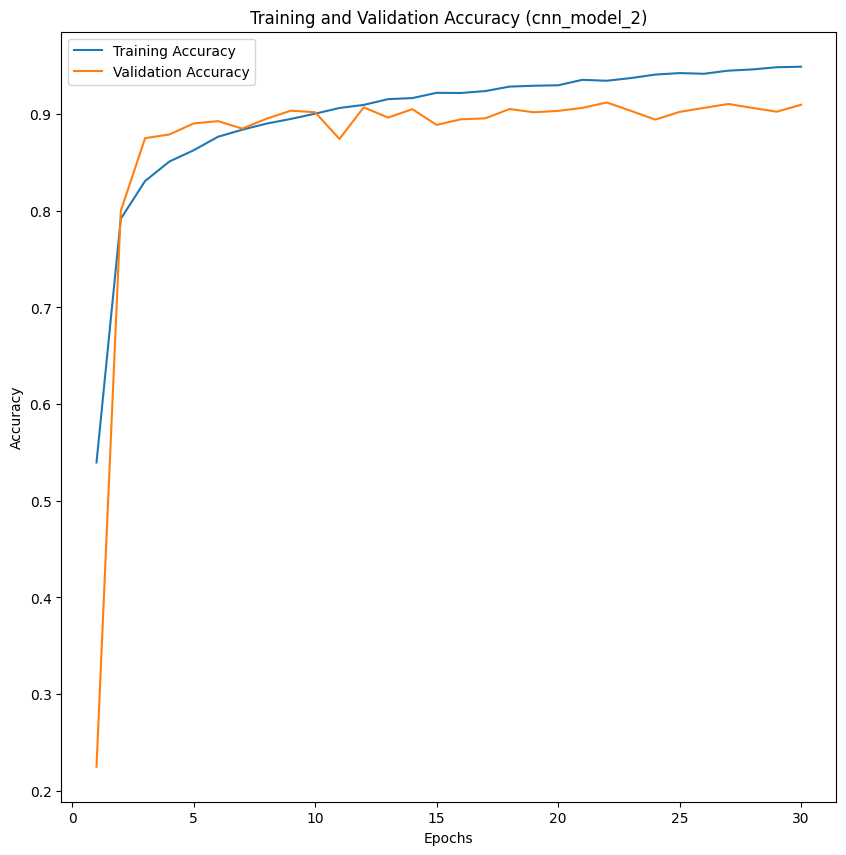

```python
dict_hist = history_cnn_model_2.history

list_ep = [i for i in range(1, 31)]
plt.figure(figsize=(10, 10))
plt.title('Training and Validation Accuracy (cnn_model_2)')
plt.plot(list_ep, dict_hist['accuracy'], label='Training Accuracy')
plt.plot(list_ep, dict_hist['val_accuracy'], label='Validation Accuracy')
plt.xlabel('Epochs')
plt.ylabel('Accuracy')
plt.legend()
plt.show()
```

**Observations:**

- Training accuracy reaches its peak at almost 95% by epoch 30. This means that the models performs well on the training data and is continually improving during the training
- Validation quickly reaches its peak, after that it fluctuates slightly between 89% and 91%, this means that the model's generalization ability wont improve with futher training
- There is only minimal overfitting, the curves staying close to eachother suggests that the model generalizes well on unseen data
- EarlyStopping could save resources, further improvement might need tuning

## **Predictions on the test data**

- Make predictions on the test set using the second model.
- Print the obtained results using the classification report and the confusion matrix.
- Final observations on the obtained results.

### **Make predictions on the test data using the second model.**

```python
test_pred = cnn_model_2.predict(X_test)

test_pred = np.argmax(test_pred, axis = -1)
```

```
563/563 ━━━━━━━━━━━━━━━━━━━━ 1s 2ms/step
```

**Note:** Earlier, we noticed that each entry of the target variable is a one-hot encoded vector, but to print the classification report and confusion matrix, we must convert each entry of y_test to a single label.

```python
y_test = np.argmax(y_test, axis = -1)
```

### **Write your final observations on the performance of the model on the test data.**

```
              precision    recall  f1-score   support

           0       0.92      0.95      0.93      1814
           1       0.84      0.95      0.89      1828
           2       0.94      0.92      0.93      1803
           3       0.87      0.90      0.88      1719
           4       0.92      0.92      0.92      1812
           5       0.91      0.90      0.91      1768
           6       0.93      0.88      0.90      1832
           7       0.96      0.89      0.92      1808
           8       0.88      0.91      0.89      1812
           9       0.94      0.88      0.91      1804

    accuracy                           0.91     18000
   macro avg       0.91      0.91      0.91     18000
weighted avg       0.91      0.91      0.91     18000

[[1717   30    6    6   11    0   13    7    8   16]
 [  10 1729    5   21   32    5    7    7    9    3]
 [   9   33 1654   21   24    2    2   20   16   22]
 [   4   27   14 1540   12   57    9   14   35    7]
 [   5   61   15   11 1675    5    9    5   12   14]
 [   1   15    9   62    5 1594   44    2   27    9]
 [  35   15    7   18   18   42 1610    6   75    6]
 [  15   89   28   19   12    4    8 1618    6    9]
 [  26   22    5   38   10   12   30    3 1647   19]
 [  44   30   20   28   13   31    8   11   38 1581]]
```

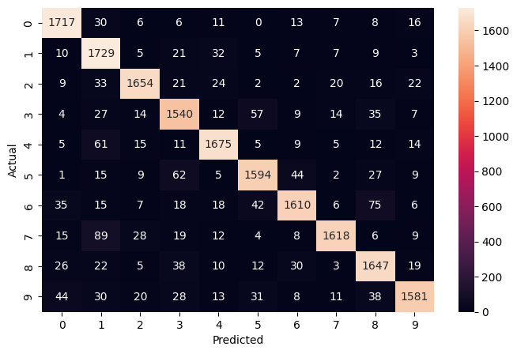

```python
#Import required functions
from sklearn.metrics import classification_report, confusion_matrix

#Print classification report
print(classification_report(y_test, test_pred))

#Print confusion matrix
print(confusion_matrix(y_test, test_pred))
cm = confusion_matrix(y_test, test_pred)
plt.figure(figsize = (8, 5))
sns.heatmap(cm, annot = True,  fmt = '.0f')
plt.ylabel('Actual')
plt.xlabel('Predicted')
plt.show()
```